# Porównanie technik estymacji VaR

Artur Karamon

8 kwietnia 2019

## Wprowadzenie

Wraz z rozwojem branży finansowej oraz ubezpieczeniowej pojawiła się potrzeba budowy prostego i intuicyjnego wskaźnika, który mówi o ryzyku portfela. W ten sposób powstała Value at risk (wartość zagrożona ryzykiem), czyli miara wyrażająca graniczny poziom straty znaleziony dla ustalonego poziomu ufności, będącego prawdopodobieństwem jej osiągnięcia. Adaptacja modelu VaR na potrzeby analizy ryzyka związanego z zaangażowaniem środków kredytowych w projekt inwestycyjny może być źródłem interesujących informacji, wspomagających decyzje zarówno kredytodawcy, jak i inwestora.  
Istnieje wiele technik wyznaczania VaR, które różnią się od siebie na poziomie strukturalnym. Niektóre z nich takie jak: **metoda historyczna**, **metoda historyczna z wagami**, **metoda EWMA** oraz **metoda bootstrap** przedstawiono oraz porównano w tej pracy. Dodatkowo wyestymowano również wartość ES - expected shortfall, która określa oczekiwaną wielkość straty. Do tych celów wykorzystano dane zawierające dzienne kursy wybranych walut z lat 2012-2018.

Wybrane waluty :

- **Euro**(*EUR*)
- **Korona Norweska**(*NOK*)
- **Baht Tajski**(*THB*)

Dla każdej waluty policzono stopy dzienne proste. Wszystkie dane umieszczono w tabeli, przedstawionej poniżej. Zbudowano też wykresy pozwalające na bardziej przejrzystą obserwację.

| data | kurs_EUR | stopy_dzien_proste_EUR | kurs_NOK | stopy_dzien_proste_NOK | kurs_THB | stopy_dzien_proste_THB |
| --- | --- | --- | --- | --- | --- | --- |
| 2012-01-03 | 4.46 | -0.001 | 0.576 | 0.001 | 0.109 | -0.004 |
| 2012-01-04 | 4.475 | 0.003 | 0.58 | 0.007 | 0.109 | 0 |
| 2012-01-05 | 4.513 | 0.009 | 0.587 | 0.012 | 0.111 | 0.018 |
| 2012-01-09 | 4.49 | -0.005 | 0.585 | -0.003 | 0.111 | -0.005 |
| 2012-01-10 | 4.488 | 0 | 0.585 | 0 | 0.111 | 0.003 |
| 2012-01-11 | 4.465 | -0.005 | 0.583 | -0.003 | 0.11 | -0.006 |
| 2012-01-12 | 4.453 | -0.003 | 0.58 | -0.006 | 0.11 | -0.003 |
| 2012-01-13 | 4.404 | -0.011 | 0.572 | -0.014 | 0.108 | -0.015 |
| 2012-01-16 | 4.406 | 0 | 0.574 | 0.004 | 0.109 | 0.009 |
| 2012-01-17 | 4.371 | -0.008 | 0.57 | -0.007 | 0.108 | -0.013 |
| 2012-01-18 | 4.349 | -0.005 | 0.566 | -0.008 | 0.107 | -0.007 |
| 2012-01-19 | 4.339 | -0.002 | 0.566 | 0 | 0.106 | -0.006 |
| 2012-01-20 | 4.326 | -0.003 | 0.565 | -0.002 | 0.106 | -0.001 |
| 2012-01-23 | 4.311 | -0.003 | 0.561 | -0.006 | 0.106 | -0.001 |
| 2012-01-24 | 4.288 | -0.005 | 0.562 | 0.001 | 0.105 | -0.012 |
| 2012-01-25 | 4.285 | -0.001 | 0.558 | -0.007 | 0.105 | -0.003 |
| 2012-01-26 | 4.243 | -0.01 | 0.554 | -0.008 | 0.103 | -0.015 |
| 2012-01-27 | 4.222 | -0.005 | 0.552 | -0.004 | 0.103 | 0.001 |
| 2012-01-30 | 4.259 | 0.009 | 0.555 | 0.005 | 0.104 | 0.01 |
| 2012-01-31 | 4.227 | -0.007 | 0.552 | -0.005 | 0.104 | -0.004 |
| 2012-02-01 | 4.193 | -0.008 | 0.548 | -0.007 | 0.103 | -0.008 |
| 2012-02-02 | 4.199 | 0.001 | 0.549 | 0.001 | 0.103 | 0.004 |
| 2012-02-03 | 4.193 | -0.002 | 0.548 | -0.003 | 0.103 | -0.001 |
| 2012-02-06 | 4.184 | -0.002 | 0.55 | 0.004 | 0.104 | 0.006 |
| 2012-02-07 | 4.182 | 0 | 0.548 | -0.003 | 0.103 | -0.009 |
| 2012-02-08 | 4.171 | -0.003 | 0.546 | -0.004 | 0.102 | -0.006 |
| 2012-02-09 | 4.177 | 0.001 | 0.548 | 0.004 | 0.102 | 0.002 |
| 2012-02-10 | 4.205 | 0.007 | 0.551 | 0.007 | 0.103 | 0.005 |
| 2012-02-13 | 4.195 | -0.002 | 0.553 | 0.003 | 0.103 | -0.002 |
| 2012-02-14 | 4.194 | 0 | 0.556 | 0.004 | 0.103 | 0.003 |

[output cut: 1733 more lines]

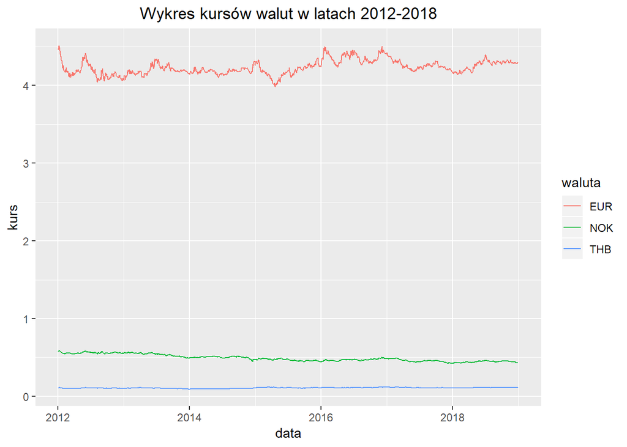

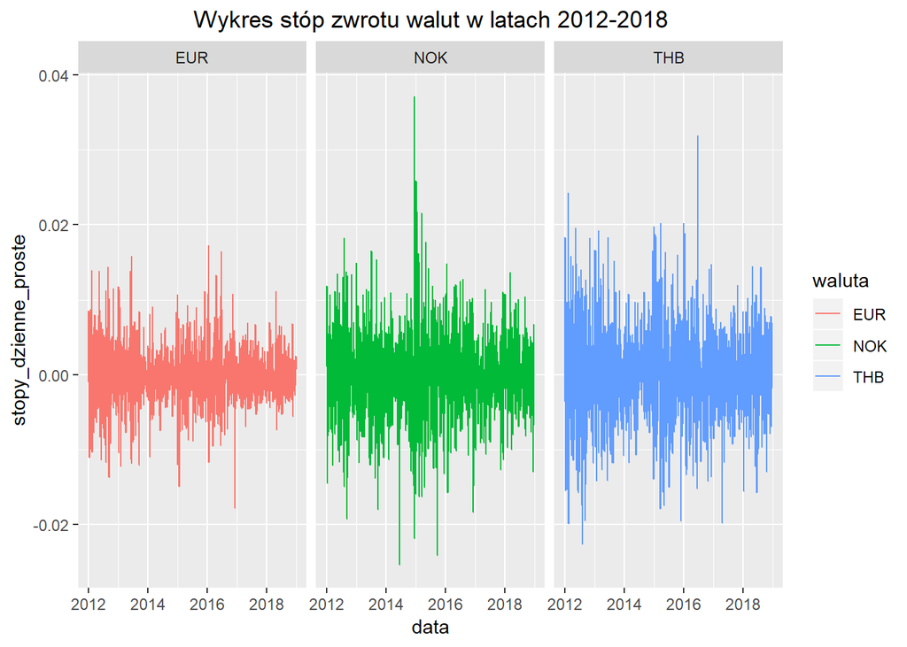

W celu lepszego zapoznania się z otrzymanym zbiorem obliczono dla niego podstawowe statystyki opisowe, takie jak średnia, mediana, odchylenie standardowe, kurtoza itp., a także wygenerowane wykresy pudełkowe oraz histogramy.

| Tabela statystyk opisowych | Tabela statystyk opisowych n | Tabela statystyk opisowych mean | Tabela statystyk opisowych sd | Tabela statystyk opisowych median | Tabela statystyk opisowych min | Tabela statystyk opisowych max | Tabela statystyk opisowych range | Tabela statystyk opisowych skew | Tabela statystyk opisowych kurtosis | Tabela statystyk opisowych se |
| --- | --- | --- | --- | --- | --- | --- | --- | --- | --- | --- |
| kurs_EUR | 1763 | 4.23343 | 0.09030 | 4.22040 | 3.98220 | 4.51350 | 0.53130 | 0.39561 | -0.02601 | 0.00215 |
| stopy_dzienne_proste_EUR | 1763 | -0.00001 | 0.00362 | -0.00010 | -0.01783 | 0.01724 | 0.03507 | 0.15186 | 2.30763 | 0.00009 |
| kurs_NOK | 1763 | 0.49106 | 0.04266 | 0.47970 | 0.42180 | 0.58740 | 0.16560 | 0.51160 | -1.02330 | 0.00102 |
| stopy_dzienne_proste_NOK | 1763 | -0.00015 | 0.00522 | -0.00022 | -0.02535 | 0.03714 | 0.06249 | 0.18527 | 3.11367 | 0.00012 |
| kurs_THB | 1763 | 0.10713 | 0.00631 | 0.10850 | 0.09160 | 0.11920 | 0.02760 | -0.61649 | -0.28792 | 0.00015 |
| stopy_dzienne_proste_THB | 1763 | 0.00005 | 0.00573 | 0.00000 | -0.02258 | 0.03191 | 0.05448 | 0.20975 | 1.60060 | 0.00014 |

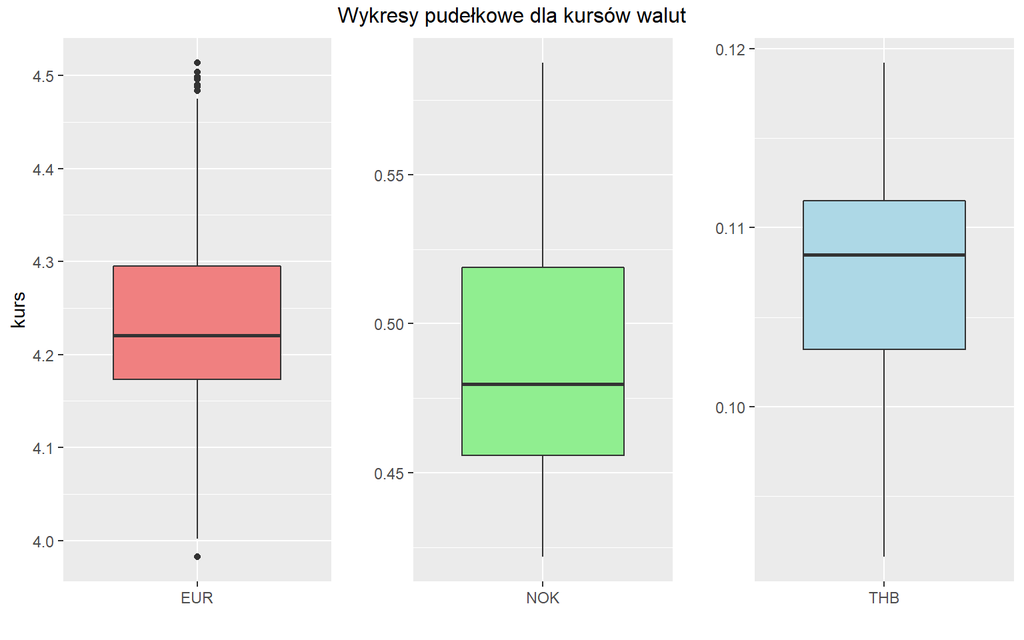

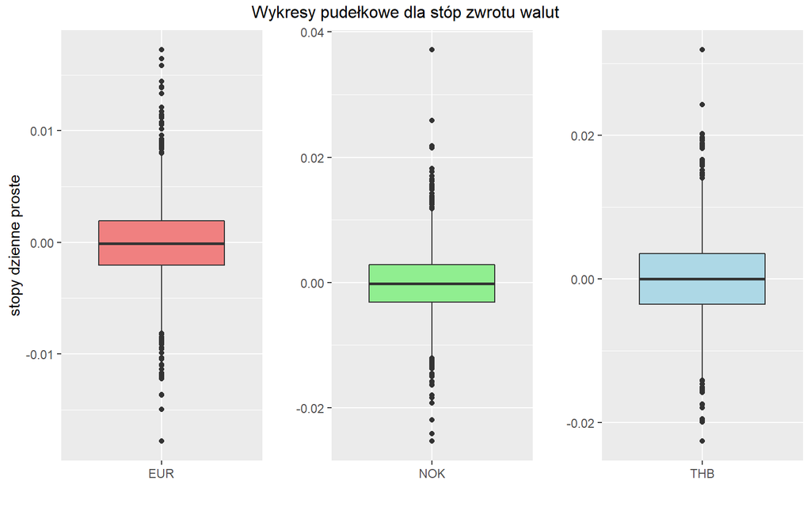

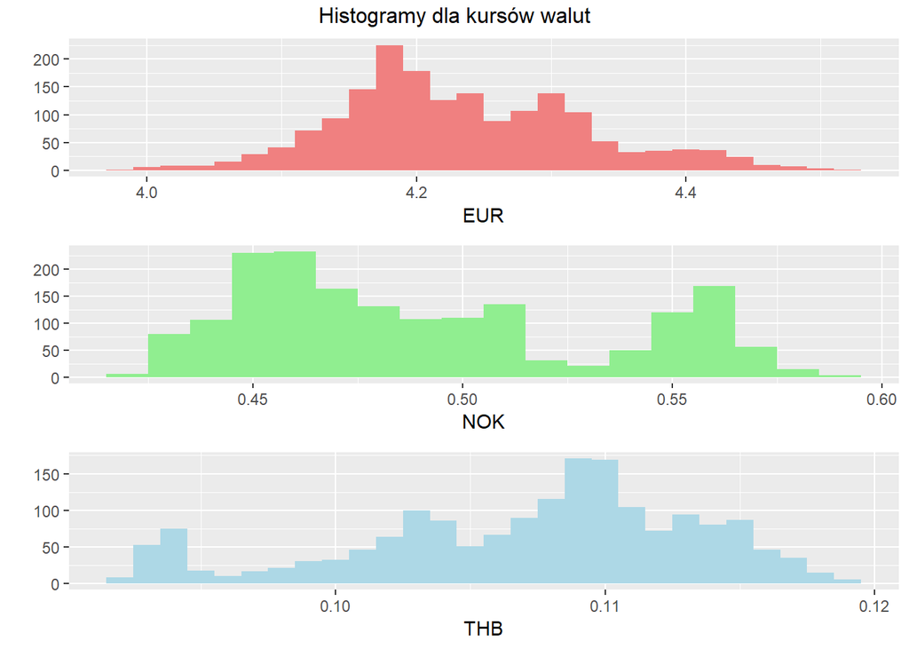

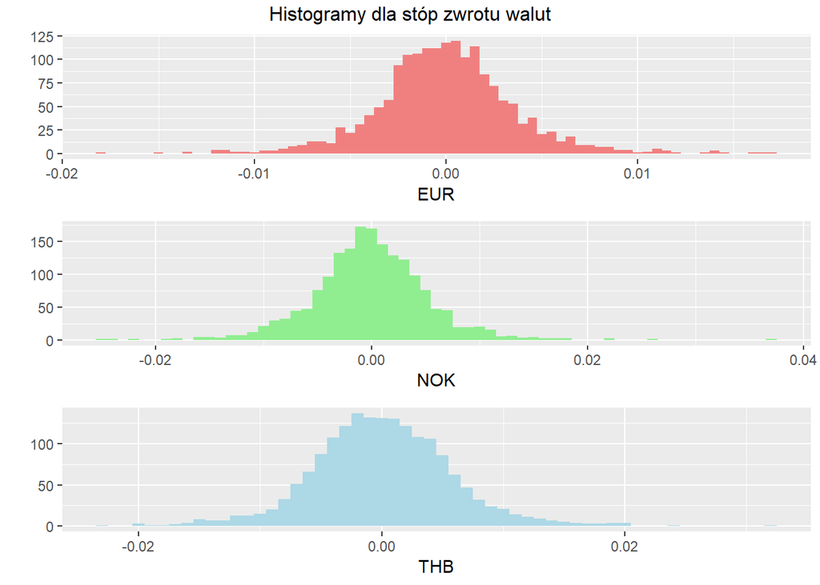

Na podstawie otrzymanych statystyk oraz wykresów można wyciągnąć cenne informacje. Najłatwiej zauważalne są dość zróżnicowane wartości średnich kursów każdej waluty. Jest to zrozumiałe, gdyż euro jest zdecydowanie “mocniejszą” walutą niż pozostałe. Rownież wahania(zmienność) kursu w przypadku euro są największe, co ma swoje potwierdzenie w odchyleniu standardowym. Jednakże już w przypadku stóp zwrotu euro w tej samej statystyce osiąga najniższe rezultaty. Ogólnie w przypadku stóp zwrotu można stwierdzić, że są one zbliżone dla wszystkich walut, szczególnie NOK i THB. Średnie wartości niewiele różnią się od 0. Jedynie THB uzyskuje dodatnią średnią dzienną stopę zwrotu. Na podstawie wykresów pudełkowych można stwierdzić, że o ile w przypadku kursów wartości odstające występują dość rzadko, to dla stóp zwrotu pojawiają się bardzo często. Ciekawe wnioski można wsnuć również w przypadku rozkładów zmiennych. Rozkłady stóp zwrotu zdecydowanie bardziej przypominają rozkład normalny oraz cechują się bardzo silnym skupieniem wartości wokół średniej, czego dowodem są wysokie wartości kurtozy. Dodatkowo rozkłady te dla każdej z walut są podobne do siebie. Na podstawie tego można zauważyć wspólne cechy, jakimi odznaczają się stopy zwrotu. Rozkłady kursów są zdecydowanie bardziej równomiernie rozłożone, brak w nich wyraźnych podobieństw między sobą.

## Analiza i wizualizacja

W badaniu wszystkie metody przeprowadzane są kolejnych 500-elementowych okien obserwacji, w skutek czego otrzymywany jest wektory wartości VaR i ES. Pozwala to na lepszą ocenę wykorzystanych metod oraz wizualizację wyników.

### Metoda historyczna

Do przeprowadzenia estymacji VaR oraz ES posłużono się wcześniej skonstruowaną funkcją, zaprezentowaną poniżej. Funkcja oblicza Value at Risk (VaR) jako kwantyl 0.01 stóp zwrotu oraz Expected Shortfall (ES).

```r
var_es_hist<-function(stopy_df){

  v_var<-NULL
  v_es<-NULL

  # pętla iterująca po oknach
  for (s in 1:(nrow(stopy_df)-499)) {
    okno<-stopy_df[s:(s+499),]

    #obliczenie varu
    var<-quantile(okno$stopy_dzienne_proste,0.01,type=7)
    v_var<-c(v_var,var)

    #obliczenie es
    ES<-mean(okno[okno$stopy_dzienne_proste<var,3])
    v_es<-c(v_es,ES)
  }

  #zapisanie danych do ramki danych
  result_df<-stopy_df[501:nrow(stopy_df),]
  result_df$VAR<-v_var[-length(v_var)]
  result_df$ES<-v_es[-length(v_es)]
  colnames(result_df)[1]<-"data_pocz"
  result_df$data_kon<-stopy_df$data[-c(1:499,length(stopy_df$data))]
  result_df<-result_df[,c("data_pocz","data_kon","kurs","stopy_dzienne_proste","VAR","ES")]

}
```

Funkcji użyto dla każdej z walut i otrzymano wyniki zaprezentowane na wykresach:

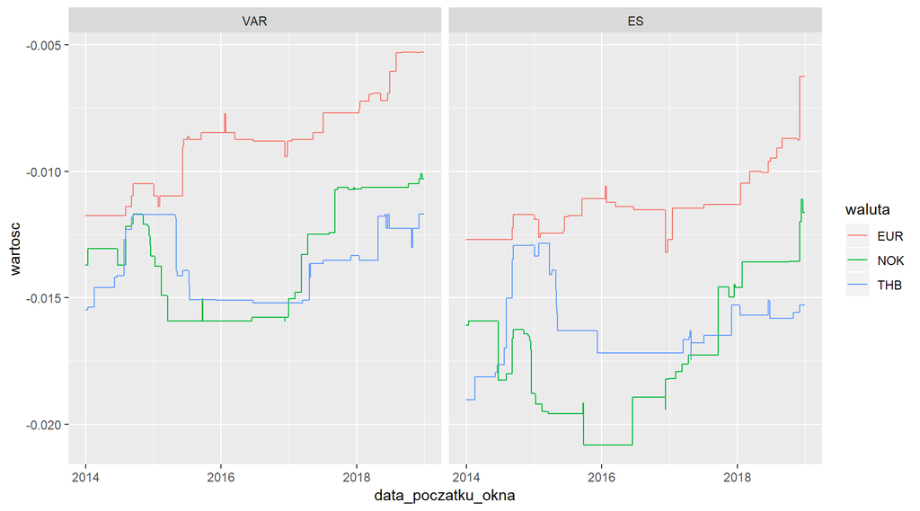

Wyniki uzyskane na podstawie tej metody wydają się być proste i logiczne. Elementem charakterystycznym, widocznym na wykresie jest “schodkowatość” krzywej VaRu. Jej zmiany są raczej niewielkie. Dodatkowo w dość długich okresach ma ona postać stałej. Wartości ES mają podobny wygląd, ale są mniejsze od VaR, co jest zgodne z konstrukcją metody jego estymacji.

### Metoda historyczna z wagami

Kolejna metoda jest jedynie udoskonaleniem poprzedniej. Funkcja działa podobnie, z tą różnicą, że stopom przyporządkowane są wagi, oznaczające prawdopodobieństwa ich wystąpienia, a kwantyl liczony jest “ręcznie” poprzez wskazanie momentu, gdy skumulowana suma posortowanych wg. stóp zwrotu wag przekracza przyjęty poziom 0.01.

```r
var_es_hist_wag<-function(stopy_df, q=0.995){

  v_var<-NULL
  v_es<-NULL

  #pętla iterująca po oknach
  for (s in 1:(nrow(stopy_df)-499)) {
    okno<-stopy_df[s:(s+499),]
    i<-1:nrow(okno)
    n<-nrow(okno)

    #wyznaczenie wag
    wagi<-(q^(n-i))*(1-q)/(1-(q^n))

    #ustalenie kolejnosci obserwacji
    kolejnosc<-rank(okno$stopy_dzienne_proste,ties.method="first")
    wagi[kolejnosc]<-wagi
    #obliczenie var
    var<-min(sort(okno$stopy_dzienne_proste)[cumsum(wagi)>0.01])

    v_var<-c(v_var,var)

    #obliczenie es
    wagi_es<-wagi[cumsum(wagi)<0.01]/0.01
    wagi_es<-c(wagi_es,1-sum(wagi_es))
    ES<-sum(wagi_es*okno$stopy_dzienne_proste[okno$stopy_dzienne_proste<=var])
    v_es<-c(v_es,ES)
  }

  #zapisanie danych do ramki danych
  result_df<-stopy_df[501:nrow(stopy_df),]
  result_df$VAR<-v_var[-length(v_var)]
  result_df$ES<-v_es[-length(v_es)]
  colnames(result_df)[1]<-"data_pocz"
  result_df$data_kon<-stopy_df$data[-c(1:499,length(stopy_df$data))]
  result_df<-result_df[,c("data_pocz","data_kon","kurs","stopy_dzienne_proste","VAR","ES")]

}
```

Tak samo jak poprzednio użyta zostaje ona dla każdej z walut. Otrzymuje się następujące wyniki:

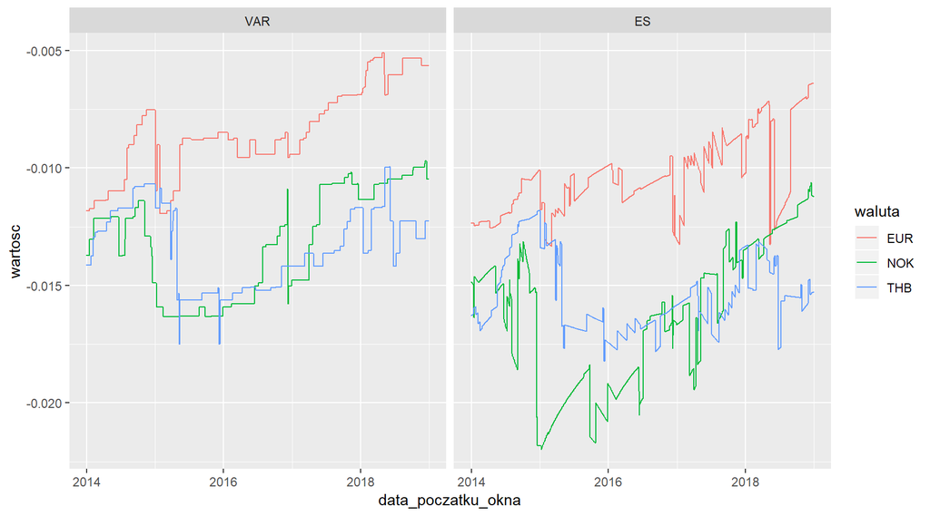

Na podstawie wykresów zaobserwować można, że w tej metodzie zarówno wartości VaRu, jak i ES są bardziej zróżnicowane. Niejednokrotnie pojawiają się znaczne skoki tych miar. W przypadku ES zanikła “schodkowatość” i zmiany tej wartości stały się bardziej płynne. Podobnie jak poprzednio widoczne są różnice dla poszczególnych walut.

### Metoda uwzględniająca heteroskedastyczność(EWMA)

Ta metoda wykorzystuje wykładniczo ważoną średnią ruchomą. Funkcja dla niej skonstruowana wylicza VaR jako kwantyl ze skorygowanych o zmienność stóp zwrotu. Podobnie dla ES. Funkcja wykorzystuje stały współczynnik lambda, ustalony domyślnie na 0.94.

```r
var_es_ewma<-function(stopy_df, lambda=0.94){

  v_var<-NULL
  v_es<-NULL

  #pętla iterująca po oknach
  for (s in 1:(nrow(stopy_df)-499)) {
    okno<-stopy_df[s:(s+499),]

    rets<-okno$stopy_dzienne_proste
    n <- length(rets)+1
    sig.s <- rep(sd(rets), n)

    #pętla obliczająca zmienność kolejnych stóp
    for (i in 2:n) {
      sig.s[i] <- sqrt(((sig.s[i-1]^2)*lambda) + ((rets[i-1]^2)*(1 - lambda)))
    }

    #skorygowanie wartości stóp o stosunek sigmy do sigmy przyszłej stopy
    wartosci<-(rets*sig.s[n])/sig.s[1:(n-1)]

    #obliczenie varu
    var<-quantile(wartosci,0.01)
    v_var<-c(v_var,var)

    #obliczenie es
    ES<-mean(wartosci[wartosci<var])
    v_es<-c(v_es,ES)
  }

  #zapisanie danych do ramki danych
  result_df<-stopy_df[501:nrow(stopy_df),]
  result_df$VAR<-v_var[-length(v_var)]
  result_df$ES<-v_es[-length(v_es)]
  colnames(result_df)[1]<-"data_pocz"
  result_df$data_kon<-stopy_df$data[-c(1:499,length(stopy_df$data))]
  result_df<-result_df[,c("data_pocz","data_kon","kurs","stopy_dzienne_proste","VAR","ES")]

  return(result_df)
}
```

Funkcja daje następujące rezultaty:

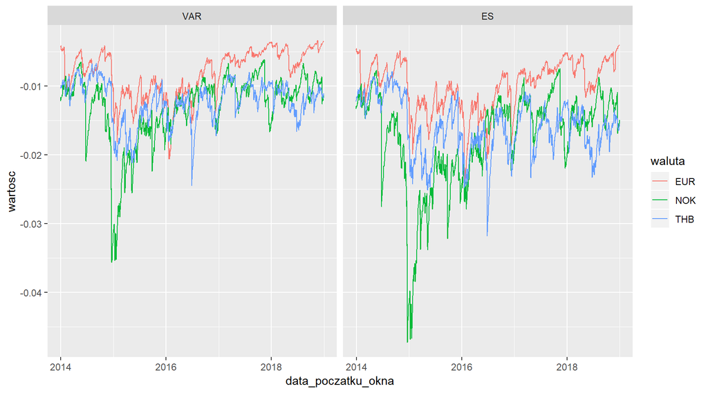

Patrząc na skalę widać, że otrzymane wyniki są jeszcze bardziej zróżnicowane w porównaniu z poprzednimi metodami. Bliskie sobie w czasie wartości VaRu znacznie się od siebie różnią. Można odnieść wrażenie braku stabilności wyników i chaotycznych, nagłych zmian wskaźników.

### Metoda bootstrap

Funkcja utworzona dla tej metody przeprowadza ustaloną ilość symulacji (domyślnie 100) dla każego okna. W każdej symulacji losowana jest ze zwracaniem ustalona ilość stóp z danego okna (domyślnie 500) i liczone są dla nich VaR oraz ES. Na końcu funkcja uśrednia otrzymane wyniki.

```r
var_es_boot<-function(stopy_df,n=500,N=100){

  v_var<-NULL
  v_es<-NULL

  #pętla iterująca po oknach
  for (s in 1:(nrow(stopy_df)-499)) {
    okno<-stopy_df[s:(s+499),]

    v_var_los<-NULL
    v_es_los<-NULL

    #pętla wywołująca kolejne symulacje
    for (i in 1:N) {
      #losowanie 500 stóp zwrotu ze zwracaniem
      stopy_los<-sample(x = okno$stopy_dzienne_proste, size = n, replace=T)

      #obliczenie varu dla wylosowanych stóp
      var_los<-quantile(stopy_los,0.01)
      v_var_los<-c(v_var_los,var_los)

      #obliczenie es dla wylosowanych stóp
      ES_los<-mean(stopy_los[stopy_los<=var_los])
      v_es_los<-c(v_es_los,ES_los)
    }

    #obliczenie średnich wartości varu i es
    var<-mean(v_var_los)
    ES<-mean(v_es_los)
    v_var<-c(v_var,var)
    v_es<-c(v_es,ES)

  }
  #zapisanie danych do ramki danych
  result_df<-stopy_df[501:nrow(stopy_df),]
  result_df$VAR<-v_var[-length(v_var)]
  result_df$ES<-v_es[-length(v_es)]
  colnames(result_df)[1]<-"data_pocz"
  result_df$data_kon<-stopy_df$data[-c(1:499,length(stopy_df$data))]
  result_df<-result_df[,c("data_pocz","data_kon","kurs","stopy_dzienne_proste","VAR","ES")]
}
```

Funkcję użyto dla wszystkich walut:

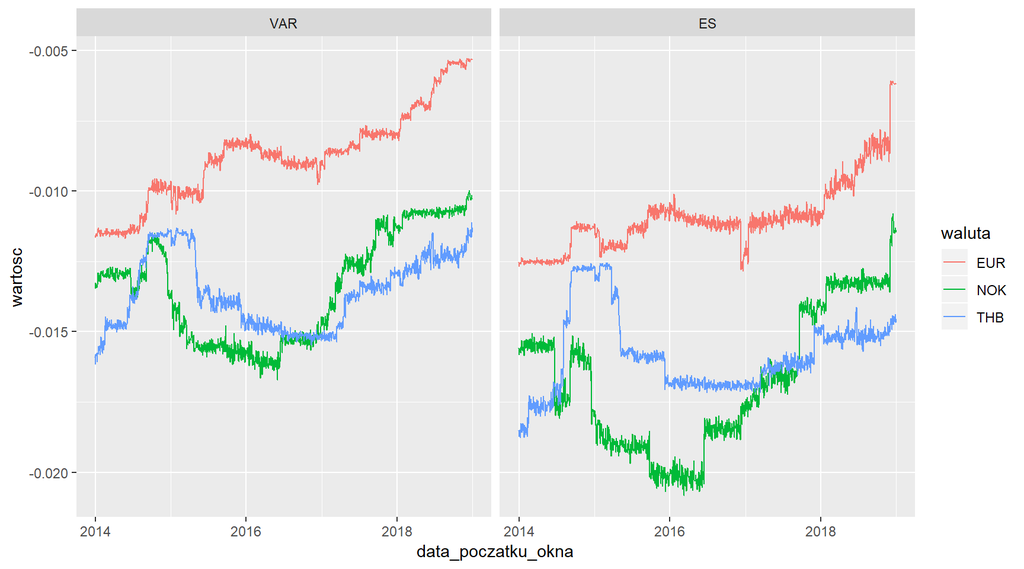

Ta metoda daje rezultaty przypominające metodę historyczną Jednak mają one niewielkie wahania, których rozmiar prawdopodobnie zależy od liczby przeprowadzanych symulacji. Im większa ich liczba tym mocniejsze wygładzenie krzywej. Można przypuszczać, że wyniki tej metody będą cechować się dużą skutecznością, szczególnie, że wykorzystuje się ją w przypadku małej ilości danych, a tutaj ten problem nie występuje..

### Testy wsteczne i porównanie

Na tym etapie pracy porównano wykorzystane wcześniej podejścia estymacji wartości narażonej na ryzyko. Oprócz wizualnego zestawienia wszystkich technik, przydatne są tutaj również testy wsteczne(backtesting) oraz inne.

Testy, które użyto w tym celu, to :

- **Test Kupca** - statystyka tego testu opiera się na log. wiarogodności i posiada rozkład chi kwadrat z 1 st. swobody, test sprawdza czy wyjątki nie pojawiają się za często oraz za rzadko,
- **Test Christoffersena** - pozwala określić, czy przekroczenia backtestingu są niezależne w czasie, statystyka tego testu również ma rozkład asymptotycznie zmierzający do chi kwadrat z 1 st. swobody,
- **Test Zasięgu** - pozwala wyszczególnić, czy w teście pojawiła się zbyt duża, bądź zbyt mała liczba wyjątków,
- **Test Wartości Rzeczywistych** - sprawdza, jak model radzi sobie dla wartości rzeczywistej, czyli wartości stopy w kolejnym dniu.

Dla każdego z testów stworzono funkcję pozwalającą na jego przeprowadzenie.

```r
KupiecTest<-function(stopy_v,VAR,alpha=0.01){
  N <- length(stopy_v)
  przekroczenia_v <- numeric(N)

  #wyznaczenie wektora przekroczeń
  przekroczenia_v[which(stopy_v <= VAR)] <- 1

  N2 <- sum(przekroczenia_v)
  stos <- N2/N

  #obliczenie statystyki testu
  test <- 2 * log(((1 - stos)^(N - N2) * stos^N2)/((1 - alpha)^(N - N2) * alpha^N2))

  #obliczenie pvalue
  pvalue <- 1-pchisq(test, df = 1)

  vect_res <- c(test,pvalue)
}

ChristoffersenTest<-function(stopy_v,VAR,alpha=0.01){
  N <- length(stopy_v)
  przekroczenia_v <- numeric(N)

  #wyznaczenie wektora przekroczeń
  przekroczenia_v[which(stopy_v <= VAR)] <- 1

  n00 = n01 = n10 = n11 = 0
  for (i in 2:N) {
    if (przekroczenia_v[i] == 0 & przekroczenia_v[i - 1] == 0)
      n00 <- n00 + 1
    if (przekroczenia_v[i] == 0 & przekroczenia_v[i - 1] == 1)
      n01 <- n01 + 1
    if (przekroczenia_v[i] == 1 & przekroczenia_v[i - 1] == 0)
      n10 <- n10 + 1
    if (przekroczenia_v[i] == 1 & przekroczenia_v[i - 1] == 1)
      n11 <- n11 + 1
  }

  pi0 <- n01/(n00 + n01)
  pi1 <- n11/(n10 + n11)
  pi <- (n01 + n11)/(n00 + n01 + n10 + n11)

  #obliczenie statystyki testu
  test1 <- -2 * log(((1 - pi)^(n00 + n10) * pi^(n01 + n11))/((1 - pi0)^n00 * pi0^n01 * (1 - pi1)^n10 * pi1^n11))

  #obliczenie pvalue
  pvalue <- 1-pchisq(test1, df = 1)
  vect_res <- c(test1, pvalue)
}

ZasiegTest<-function(stopy_v,VAR,alpha=0.01){
  N <- length(stopy_v)

  #wyznaczenie wektora przekroczeń
  l_przekroczen<-sum(stopy_v <= VAR)
  prawd<-alpha

  #obliczanie prawdopodobieństw zbyt dużej i zbyt małej liczby wyjątków
  wiele_wyj<-1-pbinom(l_przekroczen-1,N,prawd,TRUE)
  malo_wyj<-pbinom(l_przekroczen,N,prawd,TRUE)

  vect_res <- c(wiele_wyj,malo_wyj)
}
```

Następnie z wykorzystaniem wcześniejszych funkcji dla wszystkich metod i walut stworzono tabele testów, zawierające ich wyniki. Przedstawiono również wykresy porównawcze metod.

| Wyniki testów dla EUR metoda | Wyniki testów dla EUR test Kupca | Wyniki testów dla EUR test Christoffersena | Wyniki testów dla EUR test zasięgu (zbyt wiele/mało wyj) | Wyniki testów dla EUR test wartości rzeczywistych |
| --- | --- | --- | --- | --- |
| historyczna | 0.00% | 0.00% | 0.00% / 0.00% | 0.71% |
| historyczna z wagami | 6.65% | 0.00% | 6.65% / 0.00% | 0.79% |
| bootstrap | 0.00% | 0.00% | 0.00% / 0.00% | 0.71% |
| ewma | 54.79% | 0.00% | 50.75% / 4.04% | 1.03% |

| Wyniki testów dla NOK metoda | Wyniki testów dla NOK test Kupca | Wyniki testów dla NOK test Christoffersena | Wyniki testów dla NOK test zasięgu (zbyt wiele/mało wyj) | Wyniki testów dla NOK test wartości rzeczywistych |
| --- | --- | --- | --- | --- |
| historyczna | 0.00% | 0.00% | 0.00% / 0.00% | 1.11% |
| historyczna z wagami | 1.74% | 0.00% | 1.74% / 0.00% | 1.03% |
| bootstrap | 0.00% | 0.00% | 0.00% / 0.00% | 1.11% |
| ewma | 42.76% | 0.48% | 39.11% / 3.64% | 1.19% |

| Wyniki testów dla THB metoda | Wyniki testów dla THB test Kupca | Wyniki testów dla THB test Christoffersena | Wyniki testów dla THB test zasięgu (zbyt wiele/mało wyj) | Wyniki testów dla THB test wartości rzeczywistych |
| --- | --- | --- | --- | --- |
| historyczna | 0.00% | 0.00% | 0.00% / 0.00% | 1.11% |
| historyczna z wagami | 6.89% | 0.00% | 6.89% / 0.00% | 0.95% |
| bootstrap | 0.00% | 0.00% | 0.00% / 0.00% | 1.19% |
| ewma | 51.54% | 0.00% | 42.99% / 8.55% | 1.19% |

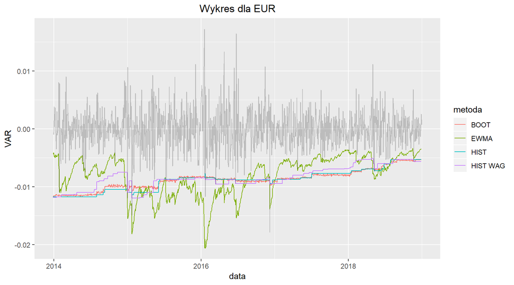

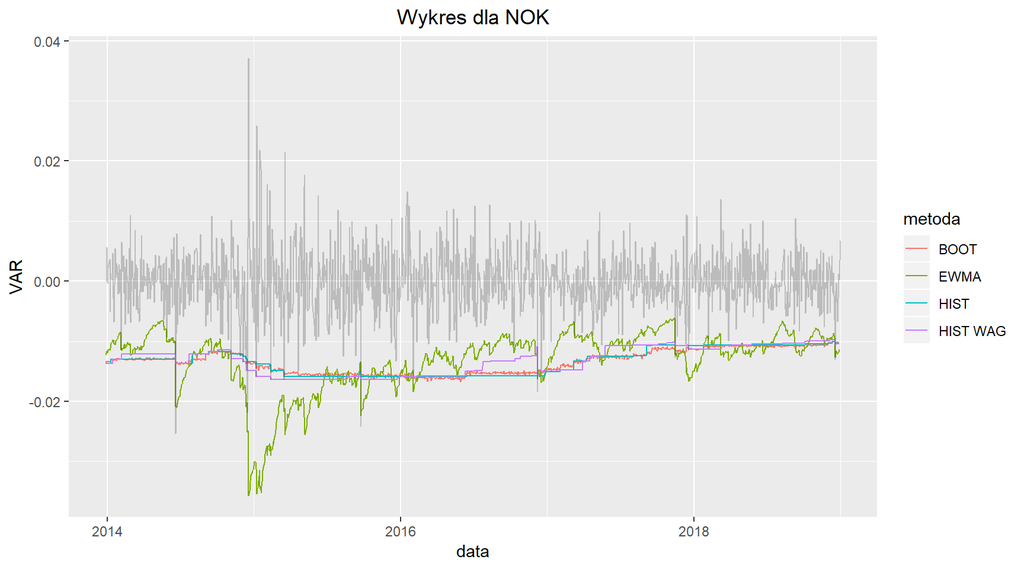

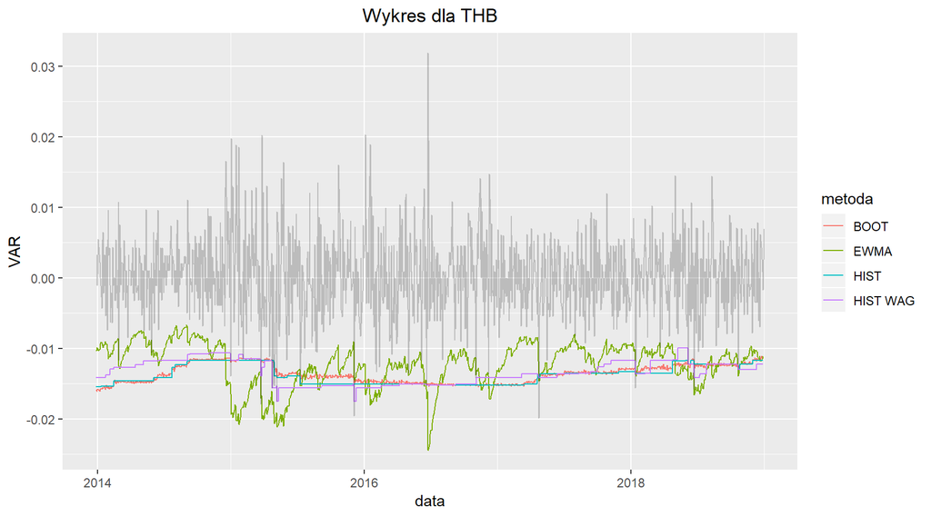

**Obserwacje i interpretacja:**  
Wykorzystane metody są bardzo odmienne. Niektóre z nich tj. ewma czy historyczna z wagami mają dużą rozbieżność wartości. W metodzie ewma VaRy z pobliskich okien potrafią różnić się od siebie nawet kilkakrotnie. Natomiast metoda historyczna oraz bootstrap są bardziej stabilne, nie mają tak drastycznych zmian wartości. Dlatego też te 2 metody wydają się mieć przewagę nad pozostałymi. Jednakże testy nie dają jednoznacznej odpowiedzi. Test Kupca dla tych metod nie powinien być interpretowany, co wynika z założeń wykorzystywanych przy konstrukcji tych metod. Dla metody historycznej z wagami błędnie zdefiniowany VaR pojawia się w od ok. 2% do ok. 7% w zależności od waluty. Dzięki testowi zasięgu wiadomo, że błędy pojawiają się jedynie za sprawą zbyt dużej liczby wyjątków. Znacznie gorzej wypada natomiast ewma, która dla testu Kupca notuje wyniki w okolicach 50%. Tutaj jako przyczyna niewłaściwej klasyfikacji pojawia się zbyt mała liczba wyjątków, ale wciąż przeważa ich zbyt duża liczba. W teście wartości rzeczywistych najlepsze rezultaty daje metoda historyczna z wagami, są one najbardziej zbliżone do 1%. Bootstrap i metoda historyczna wypadają bardzo podobnie. Dużym zaskoczeniem jest metoda ewma, która nie odstaje znacząco od pozostałych, a dla euro osiąga niemalże idealny wynik. Pod względem testu Christoffersena wszystkie metody oceniane są prawie bezbłędnie. Oznacza to, że nie ma problemów z niezależnością przekroczeń w czasie. Jedynie w przypadku ewma dla NOK pojawia się znikomy procent błędnych oszacowań VaRu.

## Zakończenie

**Wnioski:**  
Podsumowując, uzyskane wyniki są dość zróżnicowane, co daje możliwości do ciekawej interpretacji. Nie można jednoznacznie stwierdzić która z metod wypada najlepiej, szczególnie kierując się testami wstecznymi. Natomiast, biorąc pod uwagę test wartości rzeczywistych, który wydaje się być najistotniejszym wyznacznikiem z praktycznego punktu widzenia, faworytem okazuje się metoda historyczna z wagami. Zdecydowanie łatwiejsza do wskazania jest najsłabsza metoda. Ewma, mimo że w teście wartości rzeczywistych wypada bardzo dobrze, to nie radzi sobie w testach wstecznych.Prawdopodobnie wynika to ze specyficznej cechy tej metody, którą jest uwzględnienie heteroskedastyczności danych, pomijanej przez pozostałe. Możliwe, że za duży nacisk położony jest właśnie na tę cechę i warto było by zmodyfikować korektę zmienności poprzez zmianę parametru lambda. Dzięki wykorzystaniu kilku walut, które są dość odmienne pod względem siły nabywczej, stabilności i wielu innych aspektów, możliwe jest wnioskowanie na temat wykorzystania danej metody w stosunku do waluty. Najwięcej poprawnych oszacowań przypada na koronę norweską. Niełatwym okazuje się natomiast wskazanie przesłanek to powodujących, gdyż statystyki charakteryzujące tą walutę nie wyróżniają się specjalnie na tle innych. Byćmoże jedynie bardzo wysoka kurtoza może odgrywać tu jakąś rolę.  
Badanie jest bardzo złożone i pozwala na wiele możliwości modyfikacji. Byćmoże pewne z nich pozwoliły by na dokładniejsze wyniki. Wpływ na poprawność obliczeń mogły mieć zastosowane uproszczenia, tj. liczba przejść pętli, przyjmowane poziomy istotności, wielkości innych wykorzystanych danych. Ewentualne dodatkowe błędy w analizie, mogły wyniknąć z przybliżeń zastosowanych przez program.